# Bayesian VAR and VHAR Models

```r
library(bvhar)
```

```r
etf <- etf_vix[1:55, 1:3]
# Split-------------------------------
h <- 5
etf_eval <- divide_ts(etf, h)
etf_train <- etf_eval$train
etf_test <- etf_eval$test
```

# Bayesian VAR and VHAR

`var_bayes()` and `vhar_bayes()` fit BVAR and BVHAR each with various priors.

- `y`: Multivariate time series data. It should be data frame or matrix, which means that every column is numeric. Each column indicates variable, i.e. it sould be wide format.
- `p` or `har`: VAR lag, or order of VHAR
- `num_chains`: Number of chains
  - If OpenMP is enabled, parallel loop will be run.
- `num_iter`: Total number of iterations
- `num_burn`: Number of burn-in
- `thinning`: Thinning
- `coef_spec`: Coefficient prior specification.
  - Minneosta prior
    - BVAR: `set_bvar()`
    - BVHAR: `set_bvhar()` and `set_weight_bvhar()`
    - Can induce prior on $\lambda$ using `lambda = set_lambda()`
  - SSVS prior: `set_ssvs()`
  - Horseshoe prior: `set_horseshoe()`
  - NG prior: `set_ng()`
  - DL prior: `set_dl()`
- `contem_spec`: Contemporaneous prior specification.
- `cov_spec`: Covariance prior specification. Use `set_ldlt()` for homoskedastic model.
- `include_mean = TRUE`: By default, you include the constant term in the model.
- `minnesota = c("no", "short", "longrun")`: Minnesota-type shrinkage.
- `verbose = FALSE`: Progress bar
- `num_thread`: Number of thread for OpenMP
  - Used in parallel multi-chain loop
  - This option is valid only when OpenMP in user’s machine.

## Stochastic Search Variable Selection (SSVS) Prior

```r
(fit_ssvs <- vhar_bayes(etf_train, num_chains = 1, num_iter = 20, coef_spec = set_ssvs(), contem_spec = set_ssvs(), cov_spec = set_ldlt(), include_mean = FALSE, minnesota = "longrun"))
```

```
#> Call:
#> vhar_bayes(y = etf_train, num_chains = 1, num_iter = 20, coef_spec = set_ssvs(),
#>     contem_spec = set_ssvs(), cov_spec = set_ldlt(), include_mean = FALSE,
#>     minnesota = "longrun")
#>
#> BVHAR with SSVS prior + SSVS prior
#> Fitted by Gibbs sampling
#> Total number of iteration: 20
#> Number of burn-in: 10
#> ====================================================
#>
#> Parameter Record:
#> # A draws_df: 10 iterations, 1 chains, and 90 variables
#>      phi[1]    phi[2]   phi[3]   phi[4]   phi[5]    phi[6]  phi[7]   phi[8]
#> 1    0.1246   0.20256  -0.1602  -0.0399  -0.1411  -0.29451   0.665   0.1730
#> 2    0.0856  -0.08727   0.0496  -1.0544  -0.4975  -0.51124   0.604   0.2871
#> 3    0.1175   0.39026  -0.3997  -0.4904  -0.3764   0.06033   1.088   0.8538
#> 4    0.0203   0.03856  -0.0671   0.9171  -0.1068  -0.00241  -0.472  -0.6475
#> 5   -0.0957  -0.00745   0.0141   0.2069  -0.2324  -0.41881   0.135  -0.1364
#> 6    0.1214   0.11141  -0.2002   0.3122   0.0921   0.18845  -0.102   0.0825
#> 7    0.2038   0.04463   0.1374  -0.7403  -0.1705  -0.35122   0.619   1.0751
#> 8    0.0538   0.07403  -0.2746   0.7689  -0.1186   0.24863  -0.447   0.2596
#> 9   -0.0406   0.29739   0.0952  -1.6632  -0.5382  -0.56066   1.892   1.5085
#> 10   0.1080  -0.20321   0.0999  -0.7670  -0.0239  -0.55164   1.051   0.9027
#> # ... with 82 more variables
#> # ... hidden reserved variables {'.chain', '.iteration', '.draw'}
```

`autoplot()` for the fit (`bvharsp` object) provides coefficients heatmap. There is `type` argument, and the default `type = "coef"` draws the heatmap.

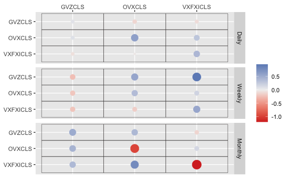

```r
autoplot(fit_ssvs)
```

## Horseshoe Prior

`coef_spec` is the initial specification by `set_horseshoe()`. Others are the same.

```r
(fit_hs <- vhar_bayes(etf_train, num_chains = 2, num_iter = 20, coef_spec = set_horseshoe(), contem_spec = set_horseshoe(), cov_spec = set_ldlt(), include_mean = FALSE, minnesota = "longrun"))
```

```
#> Call:
#> vhar_bayes(y = etf_train, num_chains = 2, num_iter = 20, coef_spec = set_horseshoe(),
#>     contem_spec = set_horseshoe(), cov_spec = set_ldlt(), include_mean = FALSE,
#>     minnesota = "longrun")
#>
#> BVHAR with Horseshoe prior + Horseshoe prior
#> Fitted by Gibbs sampling
#> Number of chains: 2
#> Total number of iteration: 20
#> Number of burn-in: 10
#> ====================================================
#>
#> Parameter Record:
#> # A draws_df: 10 iterations, 2 chains, and 124 variables
#>      phi[1]    phi[2]     phi[3]    phi[4]    phi[5]  phi[6]    phi[7]   phi[8]
#> 1    0.3921  -0.05268  -0.074338  -0.11920   0.00298   1.064   0.01377  -0.0978
#> 2   -0.0734  -0.02555   0.101854   0.24406  -0.01347   0.913   0.00776  -0.1232
#> 3    0.0614  -0.17056  -0.023383   0.35591   0.04498   1.018   0.01497   0.0443
#> 4   -0.0208  -0.21167  -0.082715   0.29275  -0.07747   0.972  -0.03674  -0.0063
#> 5    0.0240  -0.21473  -0.000909   0.20111  -0.00802   1.051   0.04101  -0.0720
#> 6    0.1186  -0.00447   0.021910   0.00658   0.05175   0.965   0.00444  -0.0121
#> 7    0.0783  -0.06972   0.037062   0.02262   0.02518   1.021   0.00290   0.0438
#> 8    0.0969   0.11061  -0.124958   0.06275  -0.01752   0.888   0.02658  -0.0398
#> 9    0.1117  -0.09341   0.125611  -0.02563   0.00331   0.734  -0.05327   0.0348
#> 10   0.1353   0.00398   0.311831   0.00282  -0.03792   0.849  -0.00370  -0.0233
#> # ... with 10 more draws, and 116 more variables
#> # ... hidden reserved variables {'.chain', '.iteration', '.draw'}
```

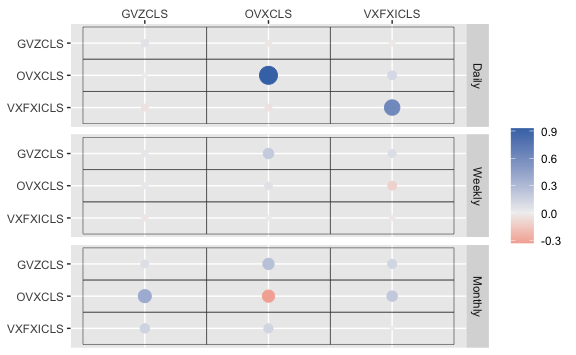

```r
autoplot(fit_hs)
```

## Minnesota Prior

```r
(fit_mn <- vhar_bayes(etf_train, num_chains = 2, num_iter = 20, coef_spec = set_bvhar(lambda = set_lambda()), cov_spec = set_ldlt(), include_mean = FALSE, minnesota = "longrun"))
```

```
#> Call:
#> vhar_bayes(y = etf_train, num_chains = 2, num_iter = 20, coef_spec = set_bvhar(lambda = set_lambda()),
#>     cov_spec = set_ldlt(), include_mean = FALSE, minnesota = "longrun")
#>
#> BVHAR with MN_Hierarchical prior + MN_Hierarchical prior
#> Fitted by Gibbs sampling
#> Number of chains: 2
#> Total number of iteration: 20
#> Number of burn-in: 10
#> ====================================================
#>
#> Parameter Record:
#> # A draws_df: 10 iterations, 2 chains, and 63 variables
#>     phi[1]   phi[2]   phi[3]   phi[4]   phi[5]  phi[6]   phi[7]   phi[8]
#> 1   0.4138  -0.0515   0.3069  -0.1077   0.4402   1.101  -0.1993  -0.0312
#> 2   0.3537  -0.2305  -0.0559  -0.1199   0.2445   0.917   0.0434   0.1963
#> 3   0.2705  -0.0465   0.0360   0.0420   0.1887   0.874   0.1031  -0.1930
#> 4   0.3118  -0.1969  -0.0404   0.0694   0.0781   0.823   0.1961   0.0728
#> 5   0.4405   0.0575   0.0506   0.0897   0.0893   0.801   0.1058   0.2704
#> 6   0.0848  -0.2301   0.1407   0.0722   0.1061   1.128   0.2398   0.2817
#> 7   0.1809  -0.0362   0.1832   0.1701   0.0527   1.200   0.3462   0.1840
#> 8   0.1078  -0.2035   0.2829   0.3574  -0.0320   1.036   0.1089  -0.0697
#> 9   0.1737  -0.0848   0.3013   0.2573  -0.0513   0.785   0.0675   0.1181
#> 10  0.2752  -0.1289   0.3415  -0.1696   0.0768   0.940  -0.4074  -0.0673
#> # ... with 10 more draws, and 55 more variables
#> # ... hidden reserved variables {'.chain', '.iteration', '.draw'}
```

## Normal-Gamma prior

```r
(fit_ng <- vhar_bayes(etf_train, num_chains = 2, num_iter = 20, coef_spec = set_ng(), cov_spec = set_ldlt(), include_mean = FALSE, minnesota = "longrun"))
```

```
#> Call:
#> vhar_bayes(y = etf_train, num_chains = 2, num_iter = 20, coef_spec = set_ng(),
#>     cov_spec = set_ldlt(), include_mean = FALSE, minnesota = "longrun")
#>
#> BVHAR with NG prior + NG prior
#> Fitted by Metropolis-within-Gibbs
#> Number of chains: 2
#> Total number of iteration: 20
#> Number of burn-in: 10
#> ====================================================
#>
#> Parameter Record:
#> # A draws_df: 10 iterations, 2 chains, and 97 variables
#>      phi[1]   phi[2]  phi[3]   phi[4]    phi[5]  phi[6]  phi[7]     phi[8]
#> 1   -0.0174  -0.1553   0.144   0.0206  -0.17653   0.105   0.280   7.59e-05
#> 2    0.0609  -0.1648   0.116   0.1234   0.09851   0.355   1.276   1.09e-04
#> 3    0.0601  -0.0281   0.107   0.6836   0.11787   0.329   1.025   1.18e-04
#> 4    0.1942  -0.0493   0.109   0.2376   0.01591  -0.105   0.816   3.30e-03
#> 5   -0.1677  -0.0718   0.124   0.0581   0.02961   0.817   0.393   8.96e-03
#> 6    0.2939  -0.1472   0.112   0.1716   0.16081   0.577   0.690  -7.27e-03
#> 7    0.0951  -0.1081   0.157   0.3563   0.22643   0.512   0.788  -2.35e-02
#> 8    0.0192   0.0252   0.396  -0.0830   0.03402   0.192   0.883  -4.25e-02
#> 9    0.0870  -0.1687   0.224  -0.1649   0.11070   0.317   1.337   1.97e-02
#> 10   0.0754  -0.1531   0.301   0.0207  -0.00271   0.174   0.842  -4.06e-02
#> # ... with 10 more draws, and 89 more variables
#> # ... hidden reserved variables {'.chain', '.iteration', '.draw'}
```

## Dirichlet-Laplace prior

```r
(fit_dl <- vhar_bayes(etf_train, num_chains = 2, num_iter = 20, coef_spec = set_dl(), cov_spec = set_ldlt(), include_mean = FALSE, minnesota = "longrun"))
```

```
#> Call:
#> vhar_bayes(y = etf_train, num_chains = 2, num_iter = 20, coef_spec = set_dl(),
#>     cov_spec = set_ldlt(), include_mean = FALSE, minnesota = "longrun")
#>
#> BVHAR with DL prior + DL prior
#> Fitted by Gibbs sampling
#> Number of chains: 2
#> Total number of iteration: 20
#> Number of burn-in: 10
#> ====================================================
#>
#> Parameter Record:
#> # A draws_df: 10 iterations, 2 chains, and 91 variables
#>       phi[1]    phi[2]     phi[3]     phi[4]    phi[5]  phi[6]    phi[7]
#> 1   -0.00240   0.02170   0.000638  -0.494874   0.24782   1.054  -0.06912
#> 2   -0.11518  -0.09074   0.002409   0.288768   0.15906   0.842   0.10505
#> 3    0.09778  -0.05666  -0.009738   0.023870   0.14767   0.794  -0.07326
#> 4    0.10159  -0.04858   0.003269  -0.009243  -0.07123   1.038   0.10176
#> 5   -0.03366  -0.03667   0.003990   0.018902  -0.02215   1.003   0.33110
#> 6   -0.03276   0.00619   0.015556   0.007572   0.40212   0.787  -0.18810
#> 7    0.07294   0.01470   0.026532  -0.001431   0.16105   0.804  -0.00594
#> 8    0.14440   0.05501  -0.079493  -0.000369   0.86305   0.865  -0.00515
#> 9    0.00942  -0.09697   0.112964   0.000574   0.00201   0.985  -0.00477
#> 10   0.05380  -0.05886  -0.033148  -0.000881  -0.00188   0.859  -0.00425
#>        phi[8]
#> 1   -4.24e-02
#> 2   -1.26e-02
#> 3   -1.66e-02
#> 4    9.74e-04
#> 5   -4.21e-04
#> 6   -3.26e-05
#> 7    2.61e-05
#> 8    3.38e-06
#> 9    1.05e-06
#> 10  -5.88e-04
#> # ... with 10 more draws, and 83 more variables
#> # ... hidden reserved variables {'.chain', '.iteration', '.draw'}
```

# Bayesian visualization

`autoplot()` also provides Bayesian visualization. `type = "trace"` gives MCMC trace plot.

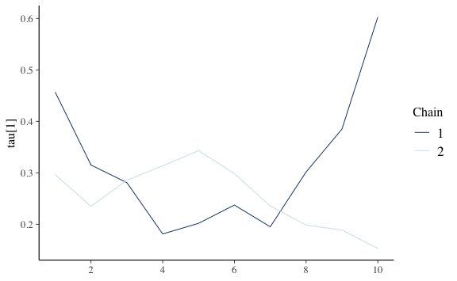

```r
autoplot(fit_hs, type = "trace", regex_pars = "tau")
```

`type = "dens"` draws MCMC density plot. If specifying additional argument `facet_args = list(dir = "v")` of `bayesplot`, you can see plot as the same format with coefficient matrix.

[figure not shown]

```r
autoplot(fit_hs, type = "dens", regex_pars = "kappa", facet_args = list(dir = "v", nrow = nrow(fit_hs$coefficients)))
```